# IODS course project

Samuli Koponen

Jagshemash!

# Part 1. Samuli’s IODS adventure!

*[Link to my repository](https://github.com/sampotarmo/IODS-project)

```r
date()
```

```
## [1] "Thu Dec 03 21:27:27 2020"
```

I’m glad I didn’t do this course on my work computer. At first there was a quite much to download, intall and update.

I’ve been using R sporadically. I learn a bit, use it for a while and then forget the whole thing. And once again I have to start from zero. The most difficult thing with R for me has been the data wrangling. So I’m quite excited for the possibility to finally tackle this problem!

Few useful links * 1. [Markdown basics](https://rmarkdown.rstudio.com/lesson-1.html) * 2. [R Community](https://www.r-statistics.com/tag/r-community/) * 3. [Rpubs](https://rpubs.com/)

Apparently, as seen above, you can not put links to lists. At least not in a normal way:

`* list 1`  
`* list 2`  
`* list 3`

..which should end up as:

- list 1
- list 2
- list 3

By now there’s some questions I’d like to get an answer. And if you, my dear reader, know the answer, please share! First and foremost, is there some way to “surf” the data? Now there’s a bunch of variables but I don’t have a clue what they contain. Sure, there’s the data dictionary provided on the course page. But I’d rather have labels for variables.

# Part 2. The adventure continues by regression!

```r
learning <- read.table("http://s3.amazonaws.com/assets.datacamp.com/production/course_2218/datasets/learning2014.txt", sep = ",", header = T)
str(learning)
```

```
## 'data.frame':    166 obs. of  7 variables:
##  $ gender  : chr  "F" "M" "F" "M" ...
##  $ age     : int  53 55 49 53 49 38 50 37 37 42 ...
##  $ attitude: num  3.7 3.1 2.5 3.5 3.7 3.8 3.5 2.9 3.8 2.1 ...
##  $ deep    : num  3.58 2.92 3.5 3.5 3.67 ...
##  $ stra    : num  3.38 2.75 3.62 3.12 3.62 ...
##  $ surf    : num  2.58 3.17 2.25 2.25 2.83 ...
##  $ points  : int  25 12 24 10 22 21 21 31 24 26 ...
```

The data comes from a survey that was carried out in Finland and has something to do with learning. The data seems to be identical with the data we made in data wrangling exercise. This, too, contains 166 observations and seven variables, two of which are background variables age and gender. Points is points from an exam. What kind of an exam and where, the legend doesn’t tell. Variable “attitude” is respondents attitude towards statistics. I found no key how to interpret the scale, but it varies from 1.4 to 5. The last three are sum variables that measures a latent features deep, surface and strategic learning.

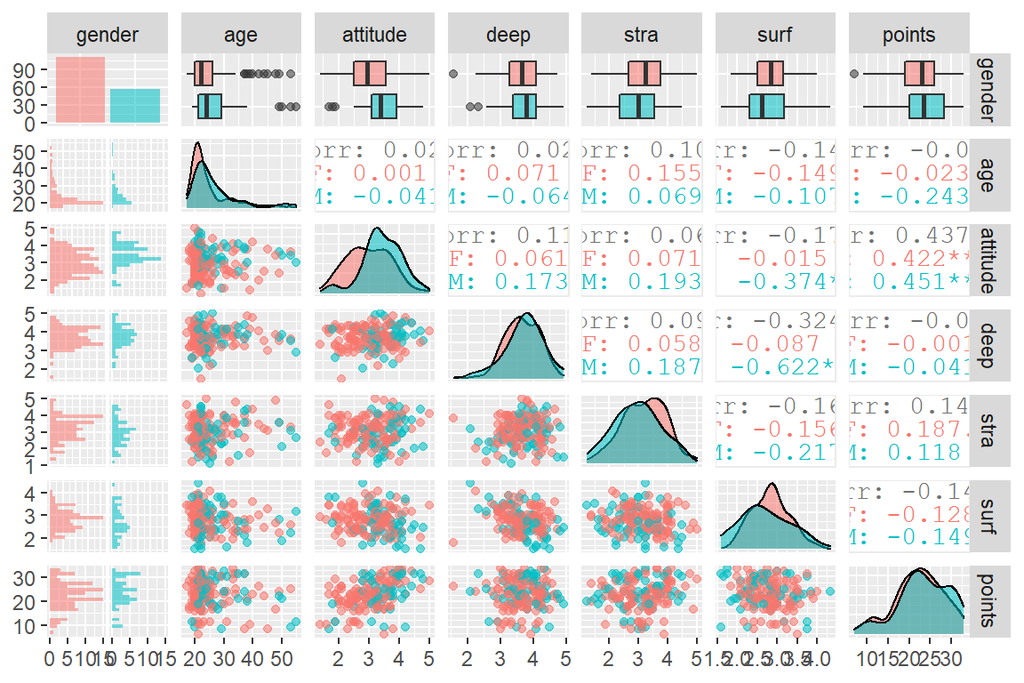

The data is summarised in the picture above. At first glance there seems to **a lot** going on. Let’s tackle the descriptive statistics first (`describe` from package `Hmisc`). There’s 110 women and 56 men. The mean age of respondents is 25.5 years, men being a little older than women. Men’s attitude towards statistics is visibly more positive than women’s.

More interesting stuff is shown in correlation matrices. From there we can gather that positive attitude towards statistics is related to better points in exam and the effect is quite similar between genders. Surface learning and deep learning have quite a strong negative correlation within men, but almost none within women. It seems that surface learning is off from deep learning and vice versa.

### Regression

I thought that the points *should* depend on learning and attitude. According to this, the first model I fitted included attitude, deep learning and strategic learning as independent variables. From the legend provided by Kimmo, I gathered that deep and strategic learning are better than surface learning in some ways. They focus more on learning than passing the class.

```r
mod1 <- lm(points ~ attitude + deep + stra, data = learning)
summary(mod1)
```

```
##
## Call:
## lm(formula = points ~ attitude + deep + stra, data = learning)
##
## Residuals:
##      Min       1Q   Median       3Q      Max
## -17.5239  -3.4276   0.5474   3.8220  11.5112
##
## Coefficients:
##             Estimate Std. Error t value Pr(>|t|)
## (Intercept)  11.3915     3.4077   3.343  0.00103 **
## attitude      3.5254     0.5683   6.203 4.44e-09 ***
## deep         -0.7492     0.7507  -0.998  0.31974
## stra          0.9621     0.5367   1.793  0.07489 .
## ---
## Signif. codes:  0 '***' 0.001 '**' 0.01 '*' 0.05 '.' 0.1 ' ' 1
##
## Residual standard error: 5.289 on 162 degrees of freedom
## Multiple R-squared:  0.2097, Adjusted R-squared:  0.195
## F-statistic: 14.33 on 3 and 162 DF,  p-value: 2.521e-08
```

The statistical test of intercept has following hypotheses:

H0: intercept is 0  
Ha: intercept is not 0

Usually the intercept is *not* the subject of interest. It simply tells the value of the depending variable when all the independent variables are zero (disregarding the measurement error). What’s more interesting are the regression estimates for the independent variables. The hypotheses concerning the regression slope estimates for each variable are:

H0: regression slope is 0 (when all other independent variables are controlled)  
Ha: regression slope is not 0 (when all other independent variables are controlled)

The p value tells us the propability of getting equal or more extreme results *if* the null hypothesis is true. So, in this case we can conclude that only attitude has a regression slope differing from zero. As instructed, we now remove the two non-significant variables from the model.

```r
mod3 <- lm(points ~ attitude, data = learning)
summary(mod3)
```

```
##
## Call:
## lm(formula = points ~ attitude, data = learning)
##
## Residuals:
##      Min       1Q   Median       3Q      Max
## -16.9763  -3.2119   0.4339   4.1534  10.6645
##
## Coefficients:
##             Estimate Std. Error t value Pr(>|t|)
## (Intercept)  11.6372     1.8303   6.358 1.95e-09 ***
## attitude      3.5255     0.5674   6.214 4.12e-09 ***
## ---
## Signif. codes:  0 '***' 0.001 '**' 0.01 '*' 0.05 '.' 0.1 ' ' 1
##
## Residual standard error: 5.32 on 164 degrees of freedom
## Multiple R-squared:  0.1906, Adjusted R-squared:  0.1856
## F-statistic: 38.61 on 1 and 164 DF,  p-value: 4.119e-09
```

Attitude towards statistics seems to have positive effect on points. At this point, I can only assume the exam has something to do with statistics. The interpretation for the regression slope is as follows:

When attitude increase by one, exam points increase by approximately 3.5

From the table above we can see that the R-squared for this model is 0.1856. This means the attitude “explains” almost 19 percent of the variance of points. In other words, other factors explain more than four fifths of the variance of the points.

### Diagnostics

Now, let’s turn to diagnostics of the model. Does the model meet the assumptions of linear regression? Does it fit the data?

There are many assumptions in linear regression. One of these is the *homoscedasticity* or constant variance. This means that the error has same variance regardless of the values of the independent variables. This can be checked using scatter plot of residuals and predicted values:

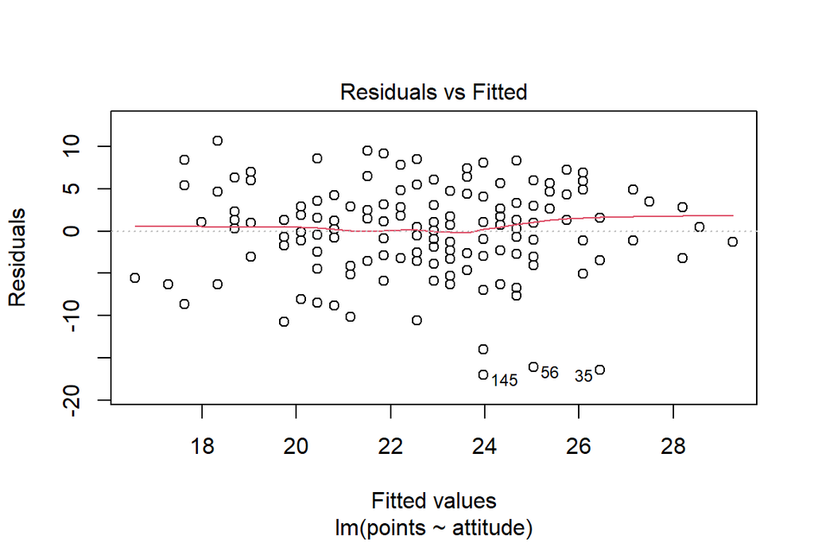

```r
plot(mod3, which = c(1))
```

What we *want* to see in the plot is that the errors aren’t “fanning out”. In the plot above, we can see that this holds true, excluding the few numbered errors at the bottom.

The second assumption is the normal distribution of errors. This can be checked with a QQ-plot:

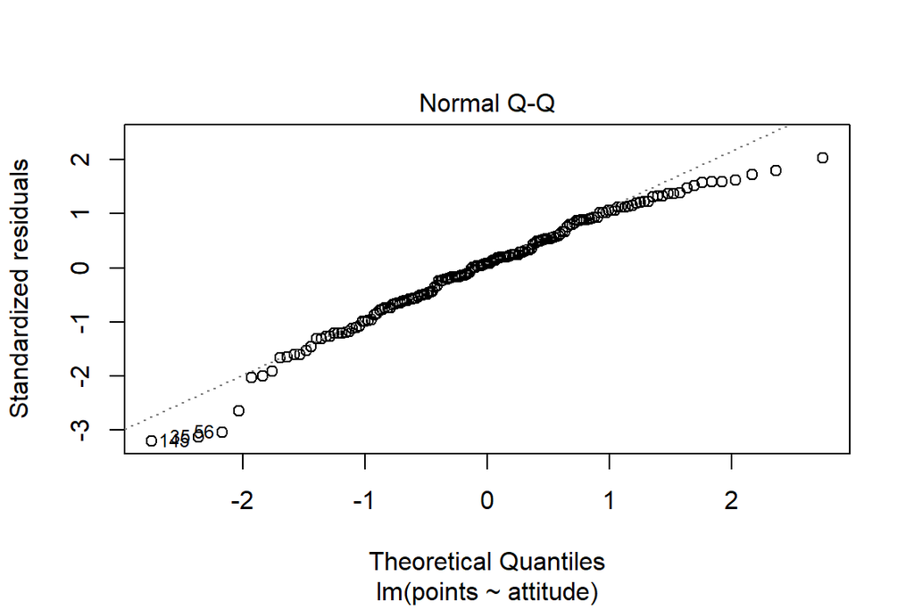

```r
plot(mod3, which = c(2))
```

Here we want to see if the points set on the straight line which would indicate the normal distribution of the errors. In this case, they set quite nicely on the line. One should notice that inspection is purely visual. Hence, the decision is rather subjective.

The last diagnostics is to see if any of the observations have too much leverage power. This means that appropriately placed observation(s) could “pull in” the regression slope. In the plot below we can see there’s only few observations that can be considered as potential outliers with too much leverage. Here too, the decision is based on visual interpretation and to my eye these few observations aren’t alarming.

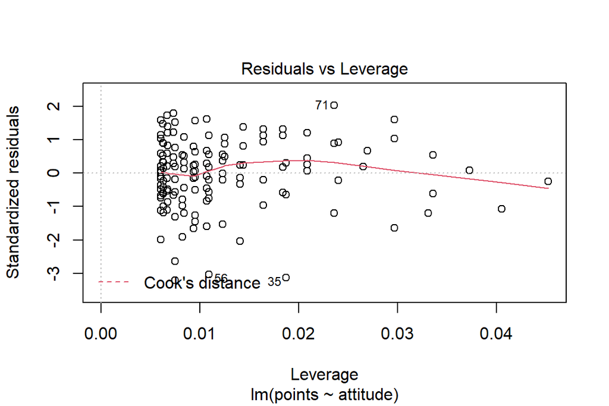

```r
plot(mod3, which = c(5))
```

Overall the model seems to fit quite nicely and doesn’t violate the assumptions. We can conclude (setting the causality aside) that positive attitude towards statistics leads to better performance in exams.

# Part 3. Regression, logistic regression

In the last two parts I didn’t reflect on my learning. The main reason for this is that I didn’t read the instructions carefully enough and didn’t know I had to do it. This rash style of working can also be seen in the quality of the exercises. All in all, I hope I learned lesson here and be more precise in the future exercises. That said, let’s continue to the logistic regression!

### Logistic regression

```r
alc <- read.csv("./data/alc_data.csv", sep = ",")
library(dplyr)
```

```r
library(GGally)
library(ggplot2)
str(alc)
```

```
## 'data.frame':    382 obs. of  36 variables:
##  $ X         : int  1 2 3 4 5 6 7 8 9 10 ...
##  $ school    : chr  "GP" "GP" "GP" "GP" ...
##  $ sex       : chr  "F" "F" "F" "F" ...
##  $ age       : int  18 17 15 15 16 16 16 17 15 15 ...
##  $ address   : chr  "U" "U" "U" "U" ...
##  $ famsize   : chr  "GT3" "GT3" "LE3" "GT3" ...
##  $ Pstatus   : chr  "A" "T" "T" "T" ...
##  $ Medu      : int  4 1 1 4 3 4 2 4 3 3 ...
##  $ Fedu      : int  4 1 1 2 3 3 2 4 2 4 ...
##  $ Mjob      : chr  "at_home" "at_home" "at_home" "health" ...
##  $ Fjob      : chr  "teacher" "other" "other" "services" ...
##  $ reason    : chr  "course" "course" "other" "home" ...
##  $ nursery   : chr  "yes" "no" "yes" "yes" ...
##  $ internet  : chr  "no" "yes" "yes" "yes" ...
```

[output cut: 22 more lines]

The data is from 382 students in Portugal or Spain, judging from the names of the schools. It consists of 35 variables. There’s social variables such as gender, age and parents education. Then there’s variables related to school, such as study time and grade points from two different courses, math and portugese. Finally there’s a bunch of variables that deals with personal life of students. These include variables like relationship with family, does one have a romantic partner and so on.

Students answered two questions regarding their alcohol use. First one is their alcohol use in working days and the another one is alcohol use in weekends. Both are on Likert scale from very low (1) to very high (5). Student was considered a high user if the mean of these two variables were more than 2. I’m interested in what leads to high alcohol use. The hypotheses are as follows:

- H1: Male gender is associated with higher probability to be high user
- H2: Better relationships with family decreases the probability of high use
- H3: Going out with friends increases the probability to be high user
- H4: Parents living apart predispose to high use

```r
variables <- c("high_use", "sex", "famrel", "goout", "Pstatus")
alc_data <- select(alc, one_of(variables))
```

Let’s examine the relationship of gender and high use first. In the following plot we can see that boys are more likely to be high users.

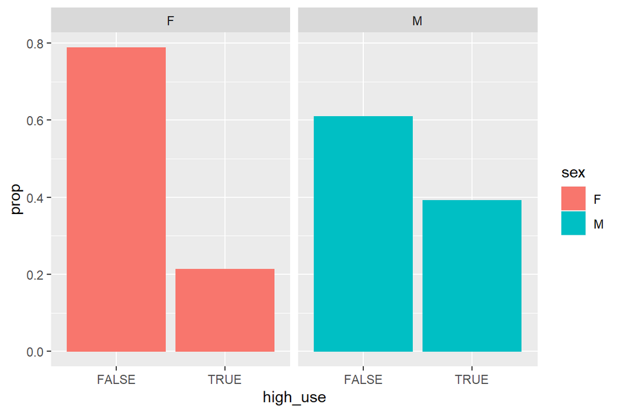

```r
ggplot(alc_data, aes(high_use, color = sex, fill = sex)) + geom_bar(aes(y = ..prop.., group = 1)) + facet_wrap(~sex)
```

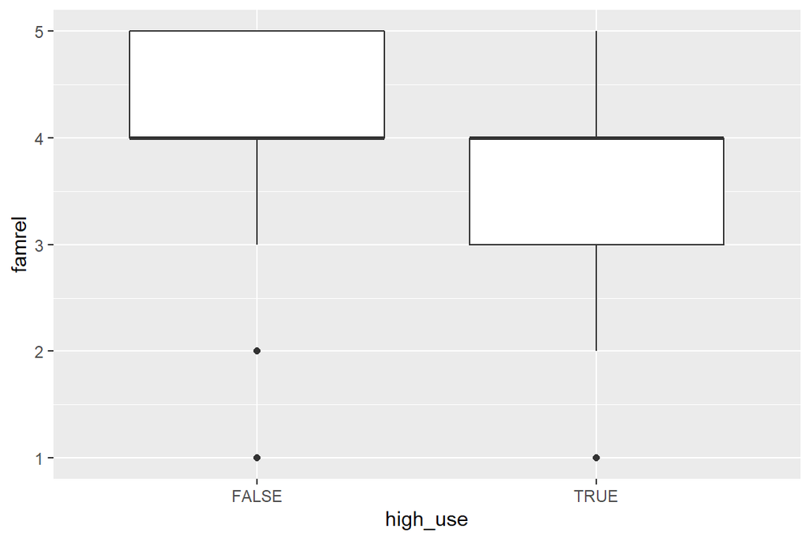

```r
ggplot(alc_data, aes(high_use, famrel)) + geom_boxplot()
```

In the plot above we can see that students who aren’t classified as high users has better relationships with family. In the next plot there’s a clear trend which indicates that students who go out with friends are prone to be high user.

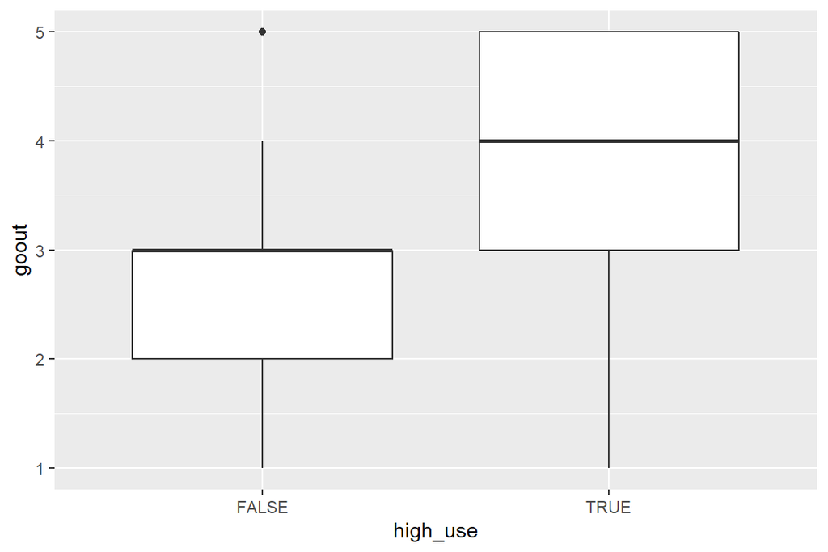

```r
ggplot(alc_data, aes(high_use, goout)) + geom_boxplot()
```

Let’s check the last hypothesis regarding parents’ living arrangements. The table below shows that the percentages are almost evenly split ant therefore there is no effect whatsoever.

```r
table <- table(alc_data$Pstatus, alc_data$high_use)
prop.table(table, 1)
```

```
##
##         FALSE      TRUE
##   A 0.6842105 0.3157895
##   T 0.7034884 0.2965116
```

Based on this brief examination three out of four hypotheses seem to be correct. However, these are just preliminary observations. Let’s make logistic regression model and see whether the hypotheses stand!

```r
m1 <- glm(high_use ~ sex + famrel + goout + Pstatus, data = alc_data, family = "binomial")
summary(m1)
```

```
##
## Call:
## glm(formula = high_use ~ sex + famrel + goout + Pstatus, family = "binomial",
##     data = alc_data)
##
## Deviance Residuals:
##     Min       1Q   Median       3Q      Max
## -1.5793  -0.7670  -0.5299   0.8231   2.5510
##
## Coefficients:
##             Estimate Std. Error z value Pr(>|z|)
## (Intercept) -2.27591    0.72348  -3.146 0.001656 **
## sexM         0.93449    0.25140   3.717 0.000201 ***
## famrel      -0.40962    0.13899  -2.947 0.003207 **
## goout        0.79703    0.12141   6.565 5.22e-11 ***
## PstatusT    -0.09695    0.41104  -0.236 0.813538
## ---
## Signif. codes:  0 '***' 0.001 '**' 0.01 '*' 0.05 '.' 0.1 ' ' 1
##
## (Dispersion parameter for binomial family taken to be 1)
##
##     Null deviance: 465.68  on 381  degrees of freedom
## Residual deviance: 393.75  on 377  degrees of freedom
## AIC: 403.75
##
## Number of Fisher Scoring iterations: 4
```

```r
OR <- coef(m1) %>% exp
CI <- confint(m1) %>% exp
cbind(OR, CI)
```

```
##                    OR      2.5 %    97.5 %
## (Intercept) 0.1027033 0.02399068 0.4135360
## sexM        2.5459191 1.56395515 4.1985857
## famrel      0.6639053 0.50377677 0.8702083
## goout       2.2189370 1.76072862 2.8370228
## PstatusT    0.9076010 0.41217213 2.0883680
```

The results indicate that the previous interpretation was correct. The same three hypotheses seem to hold true. Males are 2.5 times more likely to belong to high users. Going out with friends also increases the probability to be a high user. For every one point increase in the outgoing variable, the probality of being a high user more than doubles! On the other hand, good relations with family seems to protect against being a high user. Probability for being a high user drops one thirds for every one point increase in relationship variable. Parents’ living arrangements does not have an effect on being a high user.

```r
m2 <- glm(high_use ~ sex + famrel + goout, data = alc_data, family = "binomial")
probabilities <- predict(m2, type = "response")
alc_data <- mutate(alc_data, probability = probabilities)
alc_data <- mutate(alc_data, prediction = probability > 0.5)
table(high_use = alc_data$high_use, prediction = alc_data$prediction)
```

```
##         prediction
## high_use FALSE TRUE
##    FALSE   250   18
##    TRUE     63   51
```

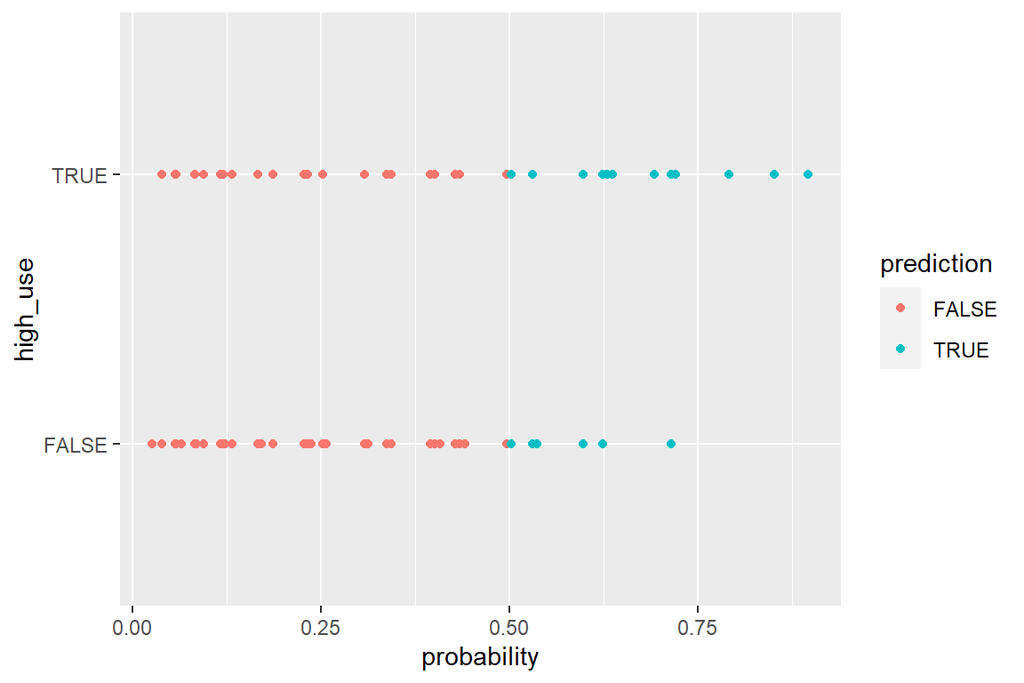

```r
ggplot(alc_data, aes(probability, high_use, col = prediction)) + geom_point()
```

From the table above we can calculate the total proportion of right and wrong predictions. Total proportion on right answers (p) is 78.8 percent. Hence, the total wrong predictions are 1-p = 21.2 percent. The plot shows the thing but atleast for me it’s more difficult to interpret.

```r
loss_func <- function(class, prob) {
  n_wrong <- abs(class - prob) > 0.5
  mean(n_wrong)
}
loss_func(class = alc_data$high_use, prob = alc_data$probability)
```

```
## [1] 0.2120419
```

The number above represents the average *wrong* predictions. By guessing the probability of right or wrong answer should be around 0.5, so we can conclude that the model is better than a sheer guess.

The next chuck performs a 10-fold cross validation. What it does, tt divides the data in ten chunks of data, uses 9 parts of them to “train” the model and tests the model with the remaining part of the data. It repeats this process nine more times changing the test chunk.

```r
library(boot)
cv <- cv.glm(data = alc_data, cost = loss_func, glmfit = m2, K = 10)
cv$delta[1]
```

```
## [1] 0.2277487
```

If I got it right, the number above is the *mean prediction error* for the ten sets of validation. It seems to work a little worse than the original model, but somewhat better than the model in Datacamp.

# Part 5. Dimensionality reduction techniques

```r
human2 <- read.table("./data/human.csv")
```

### Exploring the data

```r
library(ggplot2)
library(GGally)
str(human2)
```

```
## 'data.frame':    155 obs. of  9 variables:
##  $ Country  : chr  "Norway" "Australia" "Switzerland" "Denmark" ...
##  $ Edu2.FM  : num  1.007 0.997 0.983 0.989 0.969 ...
##  $ Labo.FM  : num  0.891 0.819 0.825 0.884 0.829 ...
##  $ Edu.Exp  : num  17.5 20.2 15.8 18.7 17.9 16.5 18.6 16.5 15.9 19.2 ...
##  $ Life.Exp : num  81.6 82.4 83 80.2 81.6 80.9 80.9 79.1 82 81.8 ...
##  $ GNI      : int  64992 42261 56431 44025 45435 43919 39568 52947 42155 32689 ...
##  $ Mat.Mor  : int  4 6 6 5 6 7 9 28 11 8 ...
##  $ Ado.Birth: num  7.8 12.1 1.9 5.1 6.2 3.8 8.2 31 14.5 25.3 ...
##  $ Parli.F  : num  39.6 30.5 28.5 38 36.9 36.9 19.9 19.4 28.2 31.4 ...
```

```r
summary(human2)
```

```
##    Country             Edu2.FM          Labo.FM          Edu.Exp
##  Length:155         Min.   :0.1717   Min.   :0.1857   Min.   : 5.40
##  Class :character   1st Qu.:0.7264   1st Qu.:0.5984   1st Qu.:11.25
##  Mode  :character   Median :0.9375   Median :0.7535   Median :13.50
##                     Mean   :0.8529   Mean   :0.7074   Mean   :13.18
##                     3rd Qu.:0.9968   3rd Qu.:0.8535   3rd Qu.:15.20
##                     Max.   :1.4967   Max.   :1.0380   Max.   :20.20
##     Life.Exp          GNI            Mat.Mor         Ado.Birth
##  Min.   :49.00   Min.   :   581   Min.   :   1.0   Min.   :  0.60
##  1st Qu.:66.30   1st Qu.:  4198   1st Qu.:  11.5   1st Qu.: 12.65
##  Median :74.20   Median : 12040   Median :  49.0   Median : 33.60
##  Mean   :71.65   Mean   : 17628   Mean   : 149.1   Mean   : 47.16
##  3rd Qu.:77.25   3rd Qu.: 24512   3rd Qu.: 190.0   3rd Qu.: 71.95
##  Max.   :83.50   Max.   :123124   Max.   :1100.0   Max.   :204.80
##     Parli.F
##  Min.   : 0.00
##  1st Qu.:12.40
##  Median :19.30
##  Mean   :20.91
##  3rd Qu.:27.95
##  Max.   :57.50
```

The data is from UNDP (United Nations Development Programme) and consists of 9 variables of which 8 are numerical. The variables are part of human development index (HDI) which measures the quality of the countries.

The variables includes measures of health and knowledge like GNI and life expectancy. These are accompanied by measures of (female?) empowerment like percentage of female representatives in country’s parliament.

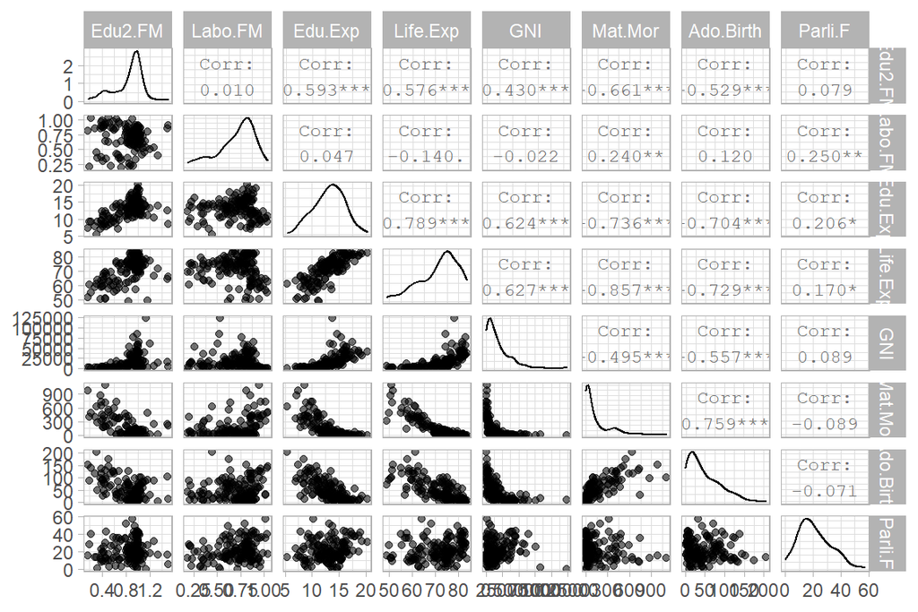

```r
ggpairs(human2[-1], mapping = aes(alpha = 0.5), progress = F, upper = list(continuous = wrap("cor", size = 3))) + theme_light()
```

### Dimension reduction

```r
m1 <- prcomp(human2[-1])
summary(m1)
```

```
## Importance of components:
##                              PC1      PC2   PC3   PC4   PC5   PC6    PC7    PC8
## Standard deviation     1.854e+04 185.5219 25.19 11.45 3.766 1.566 0.1912 0.1591
## Proportion of Variance 9.999e-01   0.0001  0.00  0.00 0.000 0.000 0.0000 0.0000
## Cumulative Proportion  9.999e-01   1.0000  1.00  1.00 1.000 1.000 1.0000 1.0000
```

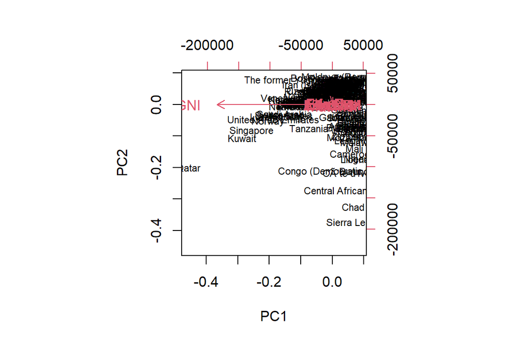

```r
biplot(m1, cex = c(0.7, 1), choices = 1:2)
```

In order to make it work, we need to standardize the variables. This means that the variables are transformed so that their mean is zero and variance is 1:

$X_{std} = \frac {x_i - \overline{X}}{var(X)}$

Let’s see if gets any better!

```r
humanstd <- scale(human2[-1])
m2 <- prcomp(humanstd)
summary(m2)
```

```
## Importance of components:
##                           PC1    PC2     PC3     PC4     PC5     PC6     PC7
## Standard deviation     2.0708 1.1397 0.87505 0.77886 0.66196 0.53631 0.45900
## Proportion of Variance 0.5361 0.1624 0.09571 0.07583 0.05477 0.03595 0.02634
## Cumulative Proportion  0.5361 0.6984 0.79413 0.86996 0.92473 0.96069 0.98702
##                            PC8
## Standard deviation     0.32224
## Proportion of Variance 0.01298
## Cumulative Proportion  1.00000
```

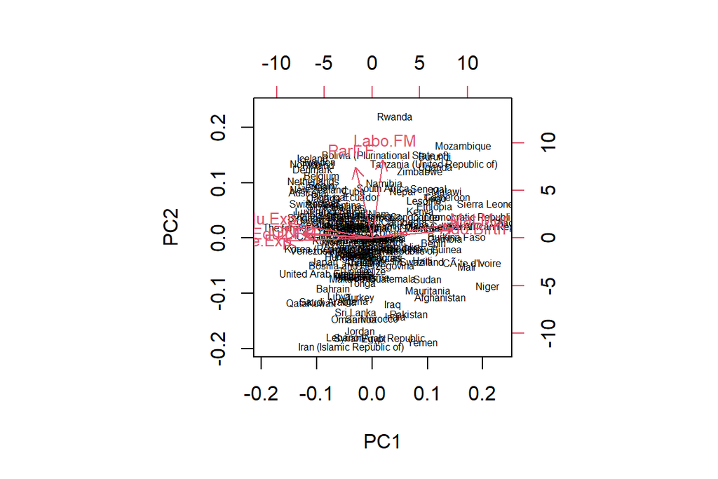

```r
biplot(m2, cex = c(0.5, 0.8), choices = 1:2)
```

### Results

Now the two first PC’s capture almost 70 percent of the total variance! The first PC seems to measure prosperity of a country. On the left are things regarded as positive: longer life expectancy, longer education and less inequality. On the right is maternal mortality and adolescent births that can be seen as negative things. The second PC measures the proportion of females in societal institutions like parliament. This PC is orthogonal with the first PC, meaning they do not correlate with each other.

# Part 6. Analysis of longitudinal data

I’m sick and don’t have energy for anything. Fortunately, I am familiar with random effect models since I used those in my master’s thesis.

I have *really* enjoyed this course! The best thing I’ve learned is easily *the tools*, R, Git and Github. I’m quite I’ll be using those a lot more from now on. I hope you do too!